# Defendants’ voices and silences in the Old Bailey courtroom, 1781-1880

Sharon Howard

14/9/2017

This is a version of the paper I gave at the [Digital Panopticon](https://www.digitalpanopticon.org) launch conference at Liverpool in September 2017.

In the interests of fostering reproducible research in the humanities, all the data and R code underlying this paper are online - details of where to find them are at the end.

## Defendant speech and verdicts in the Old Bailey

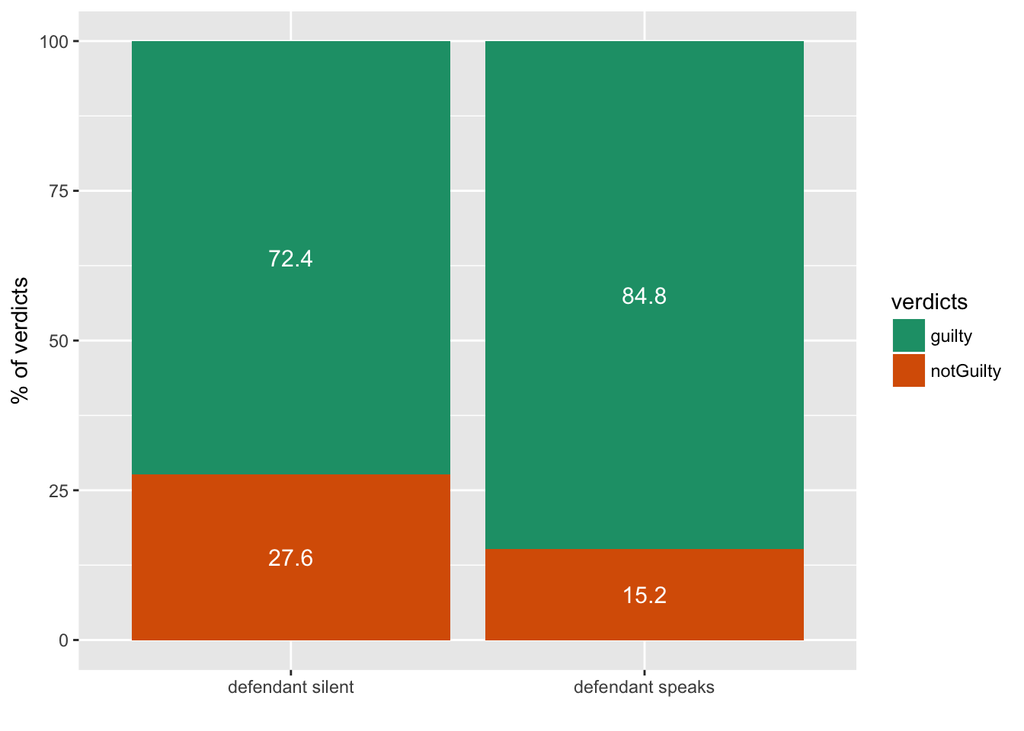

Defendants’ voices are at the heart of the Digital Panopticon Voices of Authority research theme I’ve been working on with Tim Hitchcock. We know that defendants were speaking less in Old Bailey Online trials as the 19th century went on; we’ve tended to put this in the context of growing bureaucratisation and the rise of plea bargaining.

I want to think about it slightly differently in this paper though. The graph above compares conviction/acquittal for defendants who spoke and those who remained silent, in trials containing direct speech between 1781 and 1880. It suggests that for defendants themselves, their voices were a *liability*. This won’t surprise those who’ve read historians’ depiction of the plight that defendants found themselves in 18th-century courtrooms without defence lawyers, in the “Accused Speaks” model of the criminal trial (eg Langbein, Beattie).

But this isn’t a story of bureaucrats silencing defendants (or lawyers riding in to the rescue). I want to suggest that, once defendants had alternatives to speaking for themselves (ie, representation by lawyers and/or plea bargaining), *they* made the choice to fall silent because it was often in their best interests.

## About the “Old Bailey Voices” Data

- Brings together Old Bailey Online and Old Bailey Corpus (with some additional tagging)
- Combines linguistic tagging (direct speech, speaker roles) and structured trials tagging (including verdicts and sentences)
- **Single defendant trials** only, 1781-1880
- 20700 trials in 227 OBO sessions
- 15850 of the trials contain first-person speech tagged by OBC

The Old Bailey Corpus, created by Magnus Huber, enhanced a large sample of the OBP 1720-1913 for linguistic analysis, including tagging of direct speech and tagging about speakers. [In total 407 Proceedings ca. 14 million spoken words, ca. 750,000 spoken words/decade.]

Trials with multiple defendants have been excluded from the dataset because of the added complexity of matching them to utterances (and they aren’t always individually named). Trial outcomes have also been simplified; if there are multiple verdicts or sentences only the most “serious” is retained. [Of course this begs the question of whether the dynamics and outcomes of multi-defendant trials might be different…]

Include only trials ending in guilty/not guilty verdicts, omits a handful of ‘special verdicts’ etc.

*Caveat!*

Working assumption is that nearly all silent defendants do have a lawyer and the majority of defendants who speak, don’t.

Sometimes, especially in early decades, defendants had a lawyer and also spoke. Unfortunately, the OBC tagging doesn’t distinguish between prosecution and defence lawyers, and not all lawyer speech was actually reported.

But, more seriously, is it safe to assume that ‘silent’ defendants were *really* silent? Occasionally defendant speech was actually censored in the Proceedings (in trials where other speech was reported), eg a man on trial for seditious libel in 1822 whose defence “was of such a nature as to shock the ears of every person present, and is of course unfit for publication”. But that was a very unusual, political, case. (See Google Books, Trial of Humphrey Boyle)

[However, it was suggested in questions after the presentation that maybe the issue isn’t so much total censorship as in the case above, but that the words of convicted defendants might be more likely to be *partially* censored, which would problematise analyses that centre on extent and content of their words. This could be a particular problem in 1780s and 1790s; maybe less so later on.]

So work to be done here - eg, look at trials with alternative reports specifically to consider defendants’ words.

## Distribution of trials by decade 1781-1880

Start with some broad context.

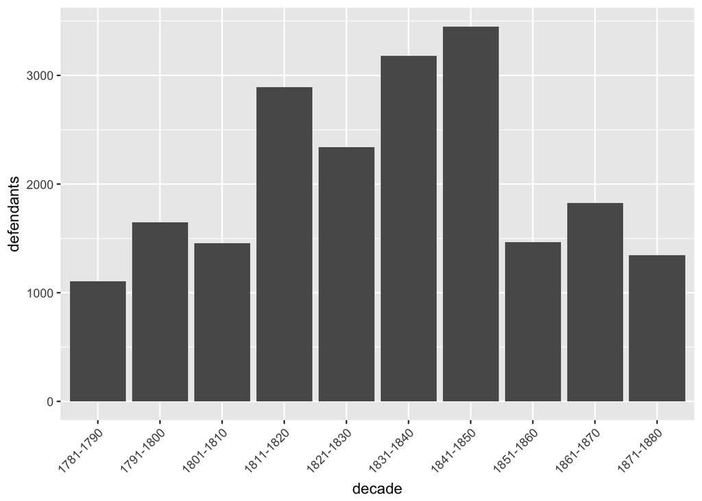

The number of cases peaked during the 1840s and dramatically fell in the 1850s. (Following the Criminal Justice Act 1855, many simple larceny cases were transferred to magistrates’ courts.)

## Percentage of trials containing speech, annually

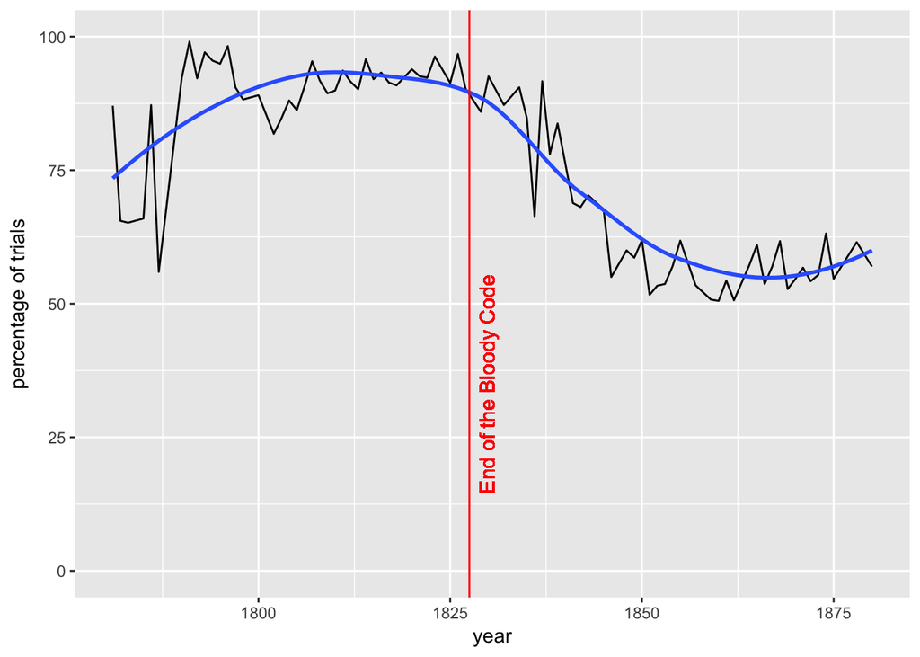

Percentage climbs from 1780s (in 1778 Proceedings became near-official record of court), peaks early 19th c and then after major criminal justice reforms of late 1820s swept away most of the Bloody Code, shown by red line, substantial fall in proportion of trials containing speech.

This was primarily due to increase in guilty pleas, which were previously rare. After the reforms, 2/3 of trials without speech are guilty pleas.

## Conviction rates annually, including guilty pleas

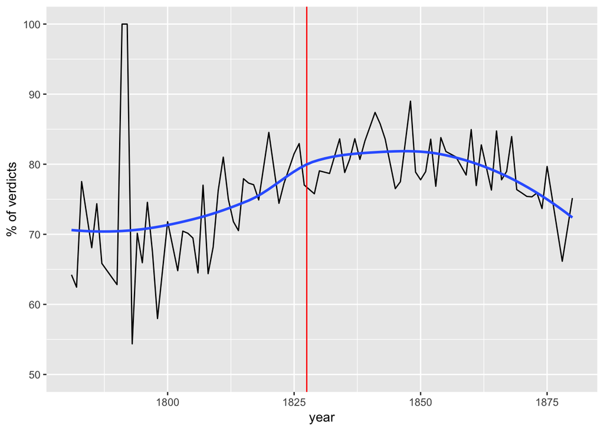

(Ignoring the spike around 1792, due to censorship of acquittals.) Gradual increase in conviction rates which declines again after mid 19th c.

But if we exclude guilty pleas and look only at jury trials, the pattern is rather different.

## Conviction rates annually, jury trials only

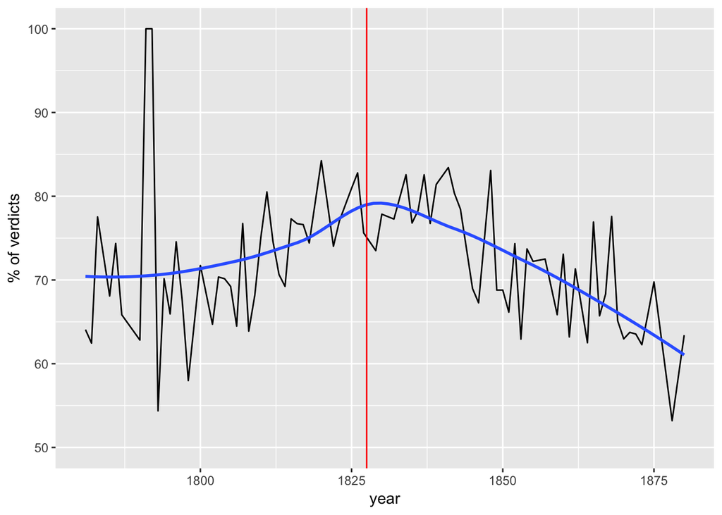

## Percentage of trials in which the defendant speaks, annually

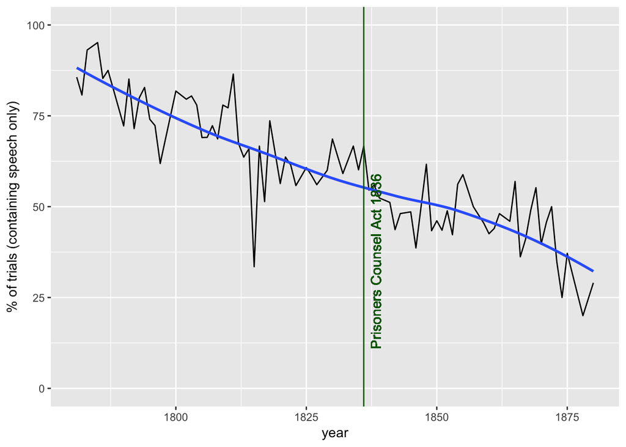

Here the green line is the Prisoners’ Counsel Act of 1836, which afforded all prisoners the right to full legal representation. But the smoothed trend line shows it had no real impact on defendant speech. Defendants had, at the judge’s discretion, been permitted defence counsel to examine and cross-examine witnesses since the 1730s.Legal historians emphasise the transformative effect of the Act; but from defendants’ point of view it seems less important; for them it was already a done deal and the Bloody Code reforms were much more significant.

## Defendant speech/silence and verdicts, by decade

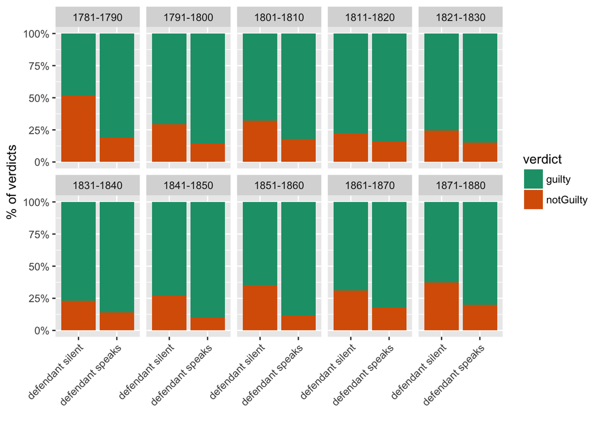

This breaks down the original graph by decade - shows that the general pattern is consistent throughout period, though exact % and proportions do vary.

## Defendant speech/silence/guilty pleas and sentences

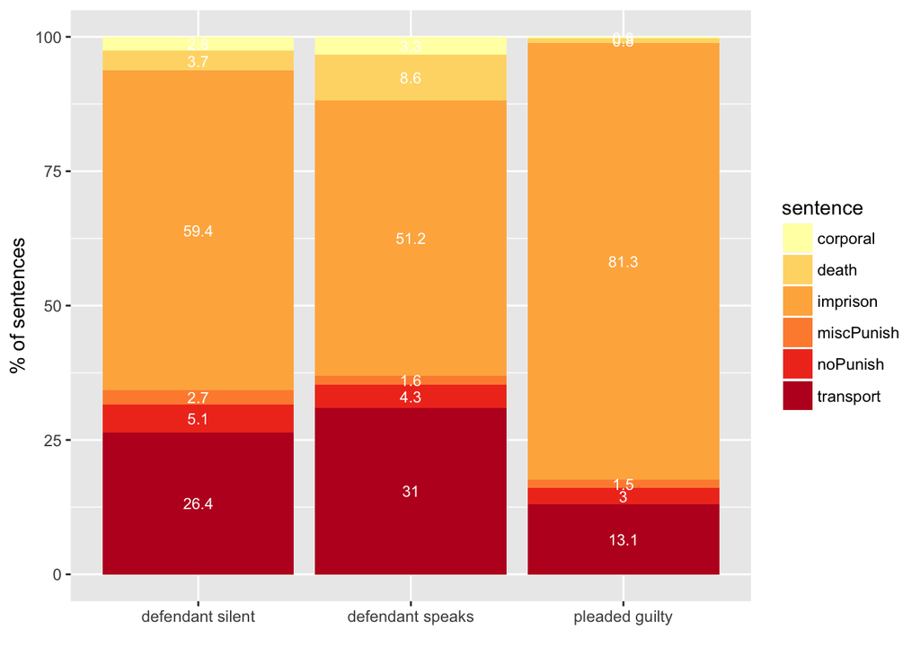

Moreover, harsher outcomes for defendants who speak continues into sentencing. Plea bargaining (though bear in mind this only really applies to c.1830-1880) -> most likely to result in imprisonment, much less likely to receive transportation (and hardly ever death) sentence. Defendants who speak are the most likely to face tougher sentences - death or transportation, more so than the silent.

(Don’t yet have actual punishments - the next big job is getting the linked Digital Panopticon life archives…)

## Defendant word counts (all words spoken in a trial)

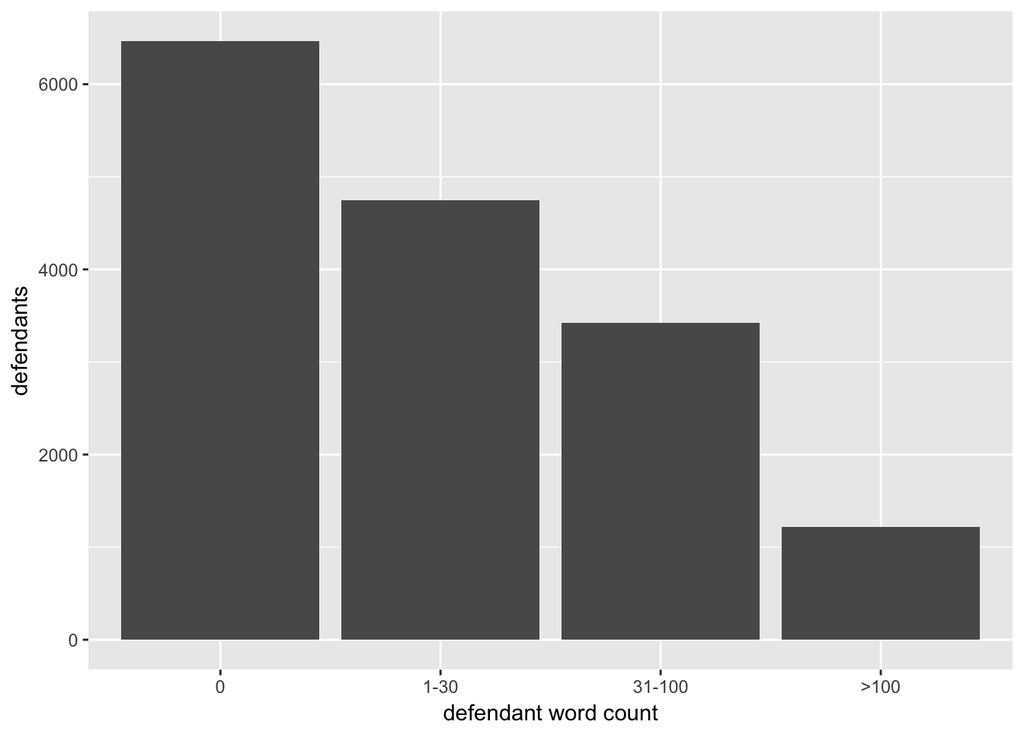

How much did defendants say? Not a lot. The largest single group of defendants is the silent (0 words). But even those who spoke usually didn’t say very much. [average overall was 55 words] Eloquent, articulate defendants few and far between!

## Defendant word counts and verdicts

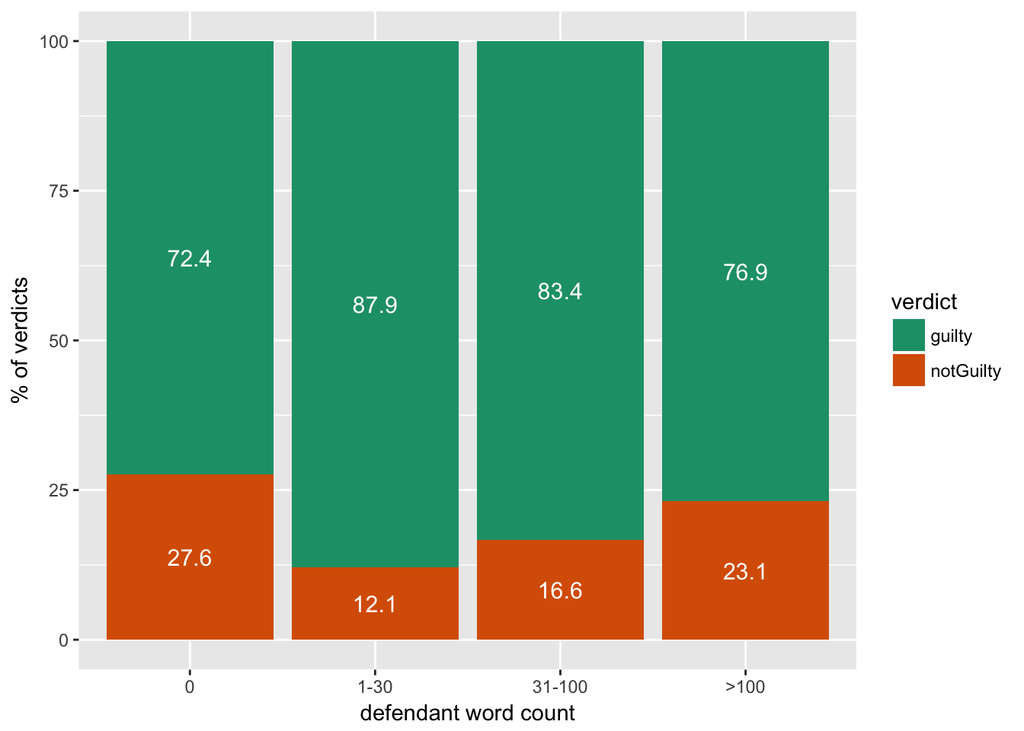

So if you did speak, it was better to say plenty!? Or in other words, more articulate defendants had a better chance of acquittal (though they were still slightly worse off than the silent).

## Defences: average word counts and verdicts

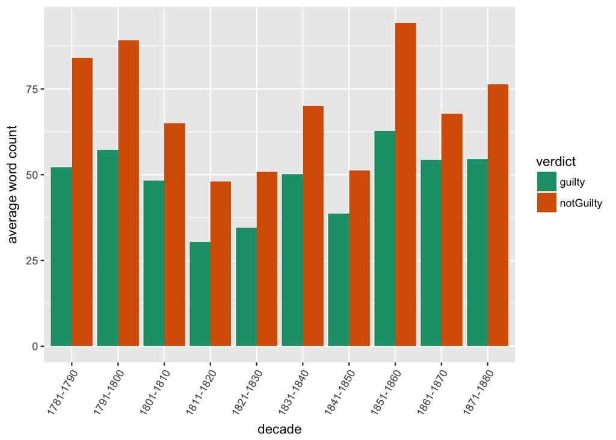

Finish with focus on defendants’ defence statements - made by nearly all defendants who spoke and for the majority the only thing they did say (a minority questioned witnesses or made statements at other points in the trial).

overall word counts of defence statements * guilty (n=7696) average wc 44.97 * notguilty (n=1414) average wc 65.15

On average, defence statements by the acquitted were longer. Again highlights that more articulate defendants do better.

Start to look more closely at *what* they say? Not possible yet to investigate in depth, but use some simple linguistic measures.

## Defences: Words least associated with acquittal

| mercy |
| --- |
| picked |
| man |
| i |
| distress |
| carry |
| along |
| them |
| beg |
| stop |
| up |
| young |

In linguistics, keywords are “items of unusual frequency in comparison with a reference corpus”. Compared the larger set of defence statements by defendants who were convicted with defence statements by defendants who were acquitted

Table above is the words *least* likely to be associated with *acquittal* - ie, the least successful defence statements…

I’d highlight:

- **mercy + beg**
- **picked** (+ perhaps **carry** is related)
- **i**
- **distress**

Remember that many defence statements were not really ‘defences’; they were more of an appeal to the judges’ clemency *after* sentencing - ‘I beg for mercy’ or claiming extenuating circumstances (‘I was in distress’) in particular. Also Playing down offence - ‘I picked up the things’.

And in general many short bare statements beginning with “I” rather than more complex narratives.

## Four hopeless short defences

I picked four of the most frequent short (non-)defences that are heavily associated with convictions, to explore a bit further. (excludes use of any of these within longer defences)

| defence | frequency | % convicted |
| --- | --- | --- |
| nothing to say | 109 | 98.17 |
| mercy | 125 | 98.40 |
| picked up/found | 223 | 93.72 |
| distress | 82 | 97.56 |

Main variants:

- I have nothing to say
- I beg for mercy/leave it to the mercy of the court/throw myself on the mercy of the court
- I picked it (them) up/found it
- I was in (great) distress/I was distressed/I did it through distress

The next four graphs show the percentage of defendant speakers who use each phrase in short defence statements in each decade.

## I have nothing to say

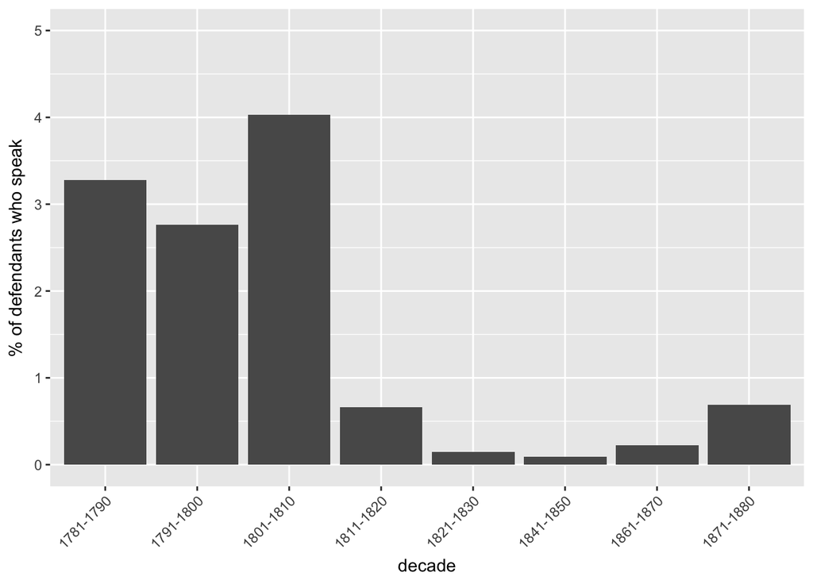

This was very popular before 1810s - peaks at use by 4% of defendants who speak in decade 1801-10 and then rapidly disappears.

## I beg for mercy/leave to the mercy of the court

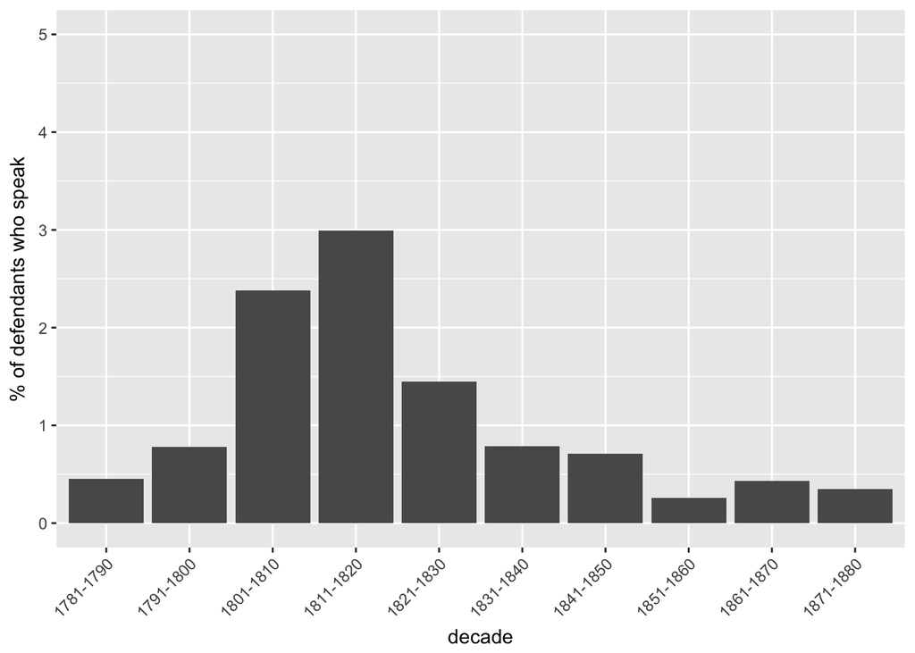

Slightly later popularity - slower decline after 1810s

## I picked it up/found it

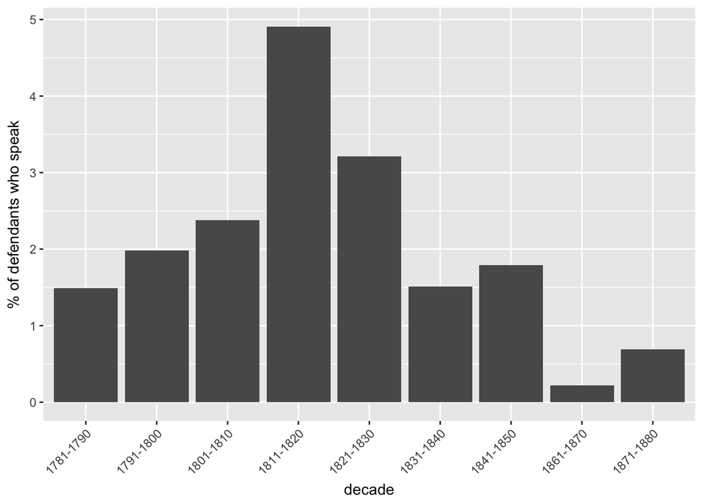

Less dramatic decline after 1820s.

## I was in distress/did it through distress

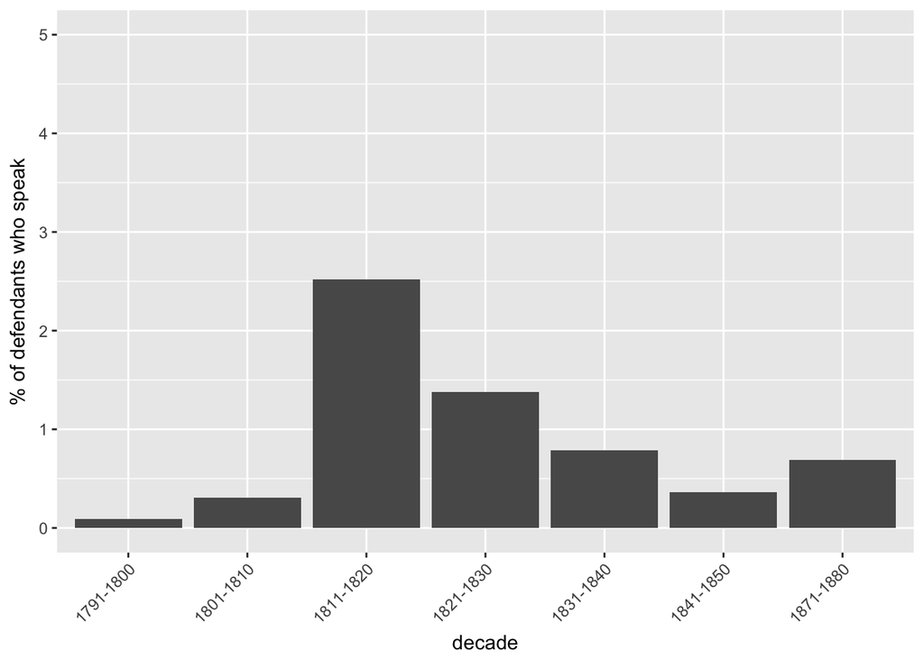

Curious that this doesn’t appear at all in 1780s; peaks 1810s.

## Conclusions

So there are variations in timing/speed of decline, but broadly, these hopeless ’non-’defence statements, which are almost certain to be followed by conviction, are all declining in use and rarely heard in the courtroom after the 1820s. That fits, it seems to me, with both the gradual decline in defendant speech and the more rapid rise from the late 1820s of plea bargaining.

First, the defence lawyer option meant that defendants were better off finding the money for a lawyer who could try to undermine the prosecution case through aggressively examining witnesses. This was happening from the 1780s onwards.

And second, the plea bargaining option from the late 1820s meant that if defendants really had no viable defence, had been caught red-handed, they were better off pleading guilty in return for a less harsh punishment.

And so: for defendants who wanted to walk free or at least lessen their punishment, if not for later historians trying to hear their voices and understand what made them tick, silence was golden.

## More stuff

- [Digital Panopticon: Voices in the Courtroom](https://www.digitalpanopticon.org/Voices_in_the_Courtroom) - more about what the Voices of Authority research theme is exploring
- [My data for Voices of Authority on Github](https://github.com/sharonhoward/voa) (including the Old Bailey Voices dataset and R code and data for this paper - among other things!)
- [Old Bailey Corpus](http://fedora.clarin-d.uni-saarland.de/oldbailey/)